# 07 - Signature scores and survival in TCGA-LAML

This stage asks whether the paper’s preleukemic signatures, PLPS (216 genes) and Stem11 (11 genes), are associated with overall survival in human AML. Data are TCGA-LAML RNA-seq (RSEM values from cBioPortal) with clinical follow-up.

Each patient is scored as the mean z-score of the signature genes across patients. Genes missing from the expression matrix are reported rather than silently dropped.

The primary test is a Cox proportional-hazards model on the continuous score, adjusted for age at diagnosis and reported as the hazard ratio per one standard deviation of score. Age is the strongest prognostic factor in AML and a likely confounder of any expression signature. The original analysis split patients at the median and ran a log-rank test; the median split discards information and the comparison was unadjusted.

Kaplan-Meier curves at the median split are kept for display. The proportional-hazards assumption is checked with Schoenfeld residuals.

```python
import pandas as pd
import numpy as np
from pathlib import Path
import matplotlib.pyplot as plt
from lifelines import CoxPHFitter, KaplanMeierFitter
from lifelines.statistics import logrank_test, proportional_hazard_test

root = Path("..")
ext = root / "data" / "external"
out_dir = root / "data" / "processed" / "07_survival"
out_dir.mkdir(parents=True, exist_ok=True)
```

## Assemble expression, clinical, and signatures

```python
expr = pd.read_csv(ext / "laml_tcga_expression.tsv", sep="\t")
expr = (expr.drop(columns=["Entrez_Gene_Id"])
            .dropna(subset=["Hugo_Symbol"])
            .drop_duplicates(subset="Hugo_Symbol")
            .set_index("Hugo_Symbol"))
expr = np.log2(expr + 1)                     # RSEM -> log2(x+1)

clin = pd.read_csv(ext / "laml_tcga_clinical.tsv", sep="\t", comment="#")
clin = clin[["PATIENT_ID", "AGE", "OS_STATUS", "OS_MONTHS"]].dropna()
clin["event"] = clin["OS_STATUS"].str.startswith("1").astype(int)
clin["time"] = pd.to_numeric(clin["OS_MONTHS"], errors="coerce")
clin = clin.dropna(subset=["time"]).query("time > 0")

# expression columns are sample IDs (TCGA-AB-XXXX-03); map to patient IDs
sample_to_patient = {c: c[:12] for c in expr.columns}
expr.columns = [sample_to_patient[c] for c in expr.columns]
expr = expr.loc[:, ~expr.columns.duplicated()]

cohort = clin[clin["PATIENT_ID"].isin(expr.columns)].copy()
print(f"Patients with expression + survival: {len(cohort)}")

signatures = {
    "PLPS":   pd.read_csv(ext / "plps.csv")["Gene"].str.strip().tolist(),
    "Stem11": pd.read_csv(ext / "stem11.csv")["Gene"].str.strip().tolist(),
}

# TCGA's older annotation uses previous symbols for two Stem11 genes; EFCC1 is absent under either name
legacy_alias = {"CAVIN2": "SDPR", "PRXL2A": "FAM213A"}
signatures = {name: [legacy_alias.get(g, g) for g in genes]
              for name, genes in signatures.items()}
```

```
Patients with expression + survival: 151
```

## Score signatures

```python
z = expr.sub(expr.mean(axis=1), axis=0).div(expr.std(axis=1).replace(0, np.nan), axis=0)

for name, genes in signatures.items():
    present = [g for g in genes if g in z.index]
    missing = sorted(set(genes) - set(present))
    print(f"{name}: {len(present)}/{len(genes)} genes found; "
          f"missing: {missing if len(missing) <= 10 else len(missing)}")
    scores = z.loc[present].mean(axis=0)
    cohort[name] = cohort["PATIENT_ID"].map(scores)

cohort = cohort.dropna(subset=list(signatures))
print(f"Final analysis cohort: {len(cohort)} patients")
```

```
PLPS: 194/216 genes found; missing: 22
Stem11: 10/11 genes found; missing: ['EFCC1']
Final analysis cohort: 151 patients
```

## Cox proportional-hazards models (primary inference)

```python
results = []
for name in signatures:
    df = cohort[["time", "event", "AGE", name]].copy()
    df[name] = (df[name] - df[name].mean()) / df[name].std()   # HR per 1 SD

    cph = CoxPHFitter()
    cph.fit(df, duration_col="time", event_col="event")
    ph = proportional_hazard_test(cph, df, time_transform="rank")

    row = cph.summary.loc[name]
    results.append({
        "signature": name,
        "HR_per_SD": np.exp(row["coef"]),
        "CI_low": np.exp(row["coef lower 95%"]),
        "CI_high": np.exp(row["coef upper 95%"]),
        "p": row["p"],
        "PH_test_p": ph.summary.loc[name, "p"],
        "n": len(df), "events": int(df["event"].sum()),
    })
    print(f"--- {name} (age-adjusted) ---")
    print(cph.summary[["exp(coef)", "exp(coef) lower 95%", "exp(coef) upper 95%", "p"]].round(4))

res_df = pd.DataFrame(results)
res_df.to_csv(out_dir / "cox_results.csv", index=False)
res_df.round(4)
```

```
--- PLPS (age-adjusted) ---
           exp(coef)  exp(coef) lower 95%  exp(coef) upper 95%      p
covariate
AGE           1.0361               1.0202               1.0521  0.000
PLPS          0.9684               0.7954               1.1790  0.749
--- Stem11 (age-adjusted) ---
           exp(coef)  exp(coef) lower 95%  exp(coef) upper 95%       p
covariate
AGE           1.0362               1.0201               1.0525  0.0000
Stem11        0.9746               0.7939               1.1965  0.8059
```

|  | signature | HR_per_SD | CI_low | CI_high | p | PH_test_p | n | events |
| --- | --- | --- | --- | --- | --- | --- | --- | --- |
| 0 | PLPS | 0.9684 | 0.7954 | 1.1790 | 0.7490 | 0.1088 | 151 | 94 |
| 1 | Stem11 | 0.9746 | 0.7939 | 1.1965 | 0.8059 | 0.5843 | 151 | 94 |

## Kaplan-Meier display (median split)

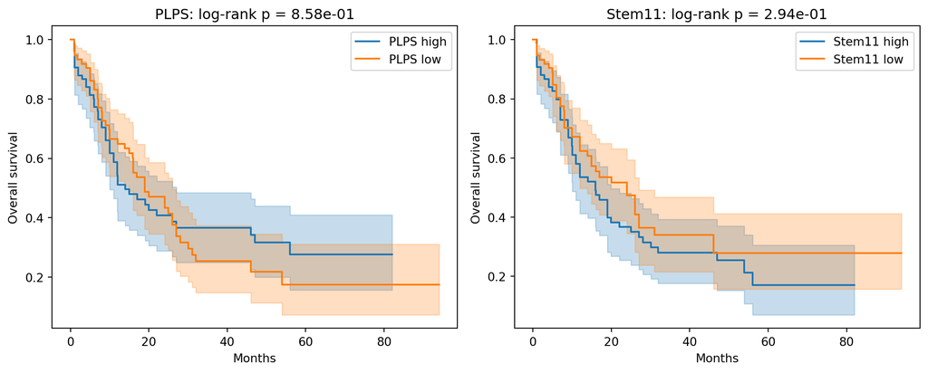

```python
fig, axes = plt.subplots(1, 2, figsize=(11, 4.5))
km_export = []
for ax, name in zip(axes, signatures):
    hi = cohort[name] >= cohort[name].median()
    lr = logrank_test(cohort.loc[hi, "time"], cohort.loc[~hi, "time"],
                      cohort.loc[hi, "event"], cohort.loc[~hi, "event"])
    for mask, lab in [(hi, f"{name} high"), (~hi, f"{name} low")]:
        km = KaplanMeierFitter()
        km.fit(cohort.loc[mask, "time"], cohort.loc[mask, "event"], label=lab)
        km.plot_survival_function(ax=ax, ci_show=True)
    ax.set_title(f"{name}: log-rank p = {lr.p_value:.2e}")
    ax.set_xlabel("Months"); ax.set_ylabel("Overall survival")
    km_export.append(cohort.assign(signature=name, group=np.where(hi, "high", "low"))
                     [["PATIENT_ID", "signature", "group", "time", "event", name]]
                     .rename(columns={name: "score"}))
plt.tight_layout(); plt.show()

pd.concat(km_export).to_csv(out_dir / "km_data.csv", index=False)
```

TCGA-LAML is a single retrospective cohort, the scores are evaluated in the same cohort they are applied to, and an age-adjusted hazard ratio is a prognostic association, not a causal effect.